# Mobile Analytics

Yuzi Liu

11/19/2018

# Data Processing

```r
getwd()
```

```
## [1] "/Users/yuziliu/Downloads"
```

```r
mobile <- read.csv("Geo-Fence Analytics.csv", header = TRUE)
```

- 1a. Create dummy variable imp_large for the large impression:
- 1b. Create dummy variables cat_entertainment, cat_social and cat_tech for app categories:
- 1c. Create dummy variable os_ios for iOS devices:

```r
mobile$imp_large <- ifelse(mobile$imp_size == "728x90", 1, 0)


mobile$cat_entertainment <- ifelse(mobile$app_topcat %in% c("IAB1","IAB1-6"), 1, 0)
mobile$cat_social <- ifelse(mobile$app_topcat == "IAB14", 1, 0)
mobile$cat_tech <- ifelse(mobile$app_topcat == "IAB19-6", 1, 0)

mobile$os_ios <- ifelse(mobile$device_os == "iOS", 1, 0)
```

- 1d. Create variable distance using Harvesine formula to calculate the distance for a pair of latitude/longitude coordinates.
- 1e. Create variable distance_squared by squaring variable distance
- 1f. Create variable ln_app_review_vol by taking natural log of app_review_vol

```r
mobile$distance = 6371*acos(cos(as_radians(mobile$device_lat))*
                     cos(as_radians(mobile$geofence_lat))*cos(as_radians(mobile$device_lon)-as_radians(mobile$geofence_lon))
                   +sin(as_radians(mobile$device_lat))*sin(as_radians(mobile$geofence_lat)))

mobile$distance_squared = mobile$distance^2
mobile$ln_app_review_vol = log(mobile$app_review_vol)
```

# Descriptive Statistics

- 2a. Summarize the data by calculating the summary statistics (i.e., mean, median, std. dev., minimum and maximum) for didclick, distance, imp_large, cat_entertainment, cat_social, cat_tech, os_ios, ln_app_review_vol and app_review_val.

```r
my_data <- as.data.frame(mobile[, c("didclick","distance","imp_large","cat_entertainment","cat_social","cat_tech","os_ios","ln_app_review_vol","app_review_val")])


stargazer(my_data, type="text", median=TRUE, digits=4, title="Summary Statistics")
```

```
##
## Summary Statistics
## ===================================================================================
## Statistic            N     Mean   St. Dev.  Min   Pctl(25) Median  Pctl(75)   Max
## -----------------------------------------------------------------------------------
## didclick          121,567 0.0068   0.0822    0       0        0       0        1
## distance          121,567 2.9837   2.6485  0.0208  1.1032  2.0209   4.0292  11.7867
## imp_large         121,567 0.2309   0.4214    0       0        0       0        1
## cat_entertainment 121,567 0.2839   0.4509    0       0        0       1        1
## cat_social        121,567 0.1251   0.3309    0       0        0       0        1
## cat_tech          121,567 0.5178   0.4997    0       0        1       1        1
## os_ios            121,567 0.2504   0.4332    0       0        0       1        1
## ln_app_review_vol 121,567 10.0568  0.6370  7.0809  9.7915  10.0872 10.0872  12.9377
## app_review_val    121,567 3.6549   0.3608  1.4000  3.4000  3.4000   3.9000  4.7000
## -----------------------------------------------------------------------------------
```

- 2b. Report the correlations among the above variables.

```r
res <- cor(my_data)
res
```

```
##                       didclick     distance    imp_large cat_entertainment
## didclick           1.000000000 -0.006628356 -0.004786218      -0.007117972
## distance          -0.006628356  1.000000000  0.020024918      -0.028992663
## imp_large         -0.004786218  0.020024918  1.000000000      -0.254731873
## cat_entertainment -0.007117972 -0.028992663 -0.254731873       1.000000000
## cat_social        -0.005623417  0.060484490 -0.185311155      -0.238133905
## cat_tech           0.012454366  0.023499545  0.414049273      -0.652575678
## os_ios            -0.002147325 -0.060281389 -0.190194050       0.312647684
## ln_app_review_vol  0.003982875 -0.157864184  0.049929790      -0.105545185
## app_review_val    -0.006523592  0.022481133 -0.321439020       0.642212363
##                     cat_social    cat_tech       os_ios ln_app_review_vol
## didclick          -0.005623417  0.01245437 -0.002147325       0.003982875
## distance           0.060484490  0.02349954 -0.060281389      -0.157864184
## imp_large         -0.185311155  0.41404927 -0.190194050       0.049929790
## cat_entertainment -0.238133905 -0.65257568  0.312647684      -0.105545185
## cat_social         1.000000000 -0.39192721  0.513672844      -0.115376574
## cat_tech          -0.391927215  1.00000000 -0.598919227       0.049503835
## os_ios             0.513672844 -0.59891923  1.000000000      -0.013523794
## ln_app_review_vol -0.115376574  0.04950383 -0.013523794       1.000000000
## app_review_val     0.194394425 -0.73206714  0.366139311       0.014457854
##                   app_review_val
## didclick            -0.006523592
## distance             0.022481133
## imp_large           -0.321439020
## cat_entertainment    0.642212363
## cat_social           0.194394425
## cat_tech            -0.732067145
## os_ios               0.366139311
## ln_app_review_vol    0.014457854
## app_review_val       1.000000000
```

```r
round(res, 4)
```

```
##                   didclick distance imp_large cat_entertainment cat_social
## didclick            1.0000  -0.0066   -0.0048           -0.0071    -0.0056
## distance           -0.0066   1.0000    0.0200           -0.0290     0.0605
## imp_large          -0.0048   0.0200    1.0000           -0.2547    -0.1853
## cat_entertainment  -0.0071  -0.0290   -0.2547            1.0000    -0.2381
## cat_social         -0.0056   0.0605   -0.1853           -0.2381     1.0000
## cat_tech            0.0125   0.0235    0.4140           -0.6526    -0.3919
## os_ios             -0.0021  -0.0603   -0.1902            0.3126     0.5137
## ln_app_review_vol   0.0040  -0.1579    0.0499           -0.1055    -0.1154
## app_review_val     -0.0065   0.0225   -0.3214            0.6422     0.1944
##                   cat_tech  os_ios ln_app_review_vol app_review_val
## didclick            0.0125 -0.0021            0.0040        -0.0065
## distance            0.0235 -0.0603           -0.1579         0.0225
## imp_large           0.4140 -0.1902            0.0499        -0.3214
## cat_entertainment  -0.6526  0.3126           -0.1055         0.6422
## cat_social         -0.3919  0.5137           -0.1154         0.1944
## cat_tech            1.0000 -0.5989            0.0495        -0.7321
## os_ios             -0.5989  1.0000           -0.0135         0.3661
## ln_app_review_vol   0.0495 -0.0135            1.0000         0.0145
## app_review_val     -0.7321  0.3661            0.0145         1.0000
```

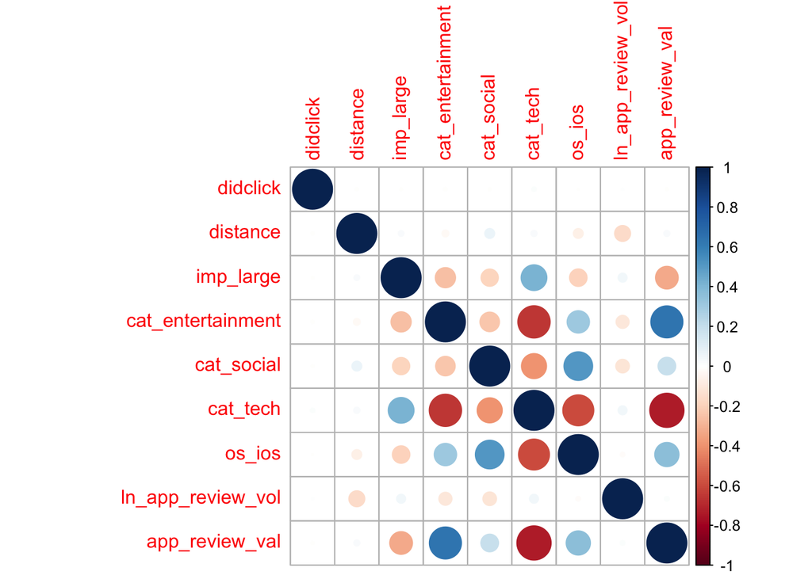

```r
corrplot(res, method = "circle")
```

- 2c. Plot the relationship of distance (x-axis) and click-through-rate (y-axis), and any other pairs of variables of interest. Bin the continuous “distance” into discrete “distance_group” where (0, 0.5] –>1, (0.5, 1] –> 2, (1, 2] –> 3, (2,4] –>4, (4, 7] –> 5, (7, 10] –> 6, >10 –>7.

```r
mobile$distance_group = ifelse(mobile$distance>0 & mobile$distance <= 0.5, 1,
                               ifelse(mobile$distance <= 1, 2,
                                      ifelse(mobile$distance <= 2, 3,
                                             ifelse(mobile$distance <= 4, 4,
                                                    ifelse(mobile$distance <= 7, 5,
                                                           ifelse(mobile$distance <=10, 6, 7))))))

impressions = ddply(mobile, c("distance_group"), summarise, nrows = length(distance_group))

didclick_group = aggregate(mobile$didclick, by=list(distance_group=mobile$distance_group), FUN=sum)


clickthrough  = merge(impressions, didclick_group, by = "distance_group")
clickthrough$ctr = clickthrough$x / clickthrough$nrows
clickthrough
```

| distance_group | nrows | x | ctr |
| --- | --- | --- | --- |
| 1 | 7324 | 60 | 0.008192245 |
| 2 | 19402 | 159 | 0.008195031 |
| 3 | 33470 | 235 | 0.007021213 |
| 4 | 30513 | 177 | 0.005800806 |
| 5 | 18267 | 116 | 0.006350249 |
| 6 | 7715 | 54 | 0.006999352 |
| 7 | 4876 | 27 | 0.005537326 |

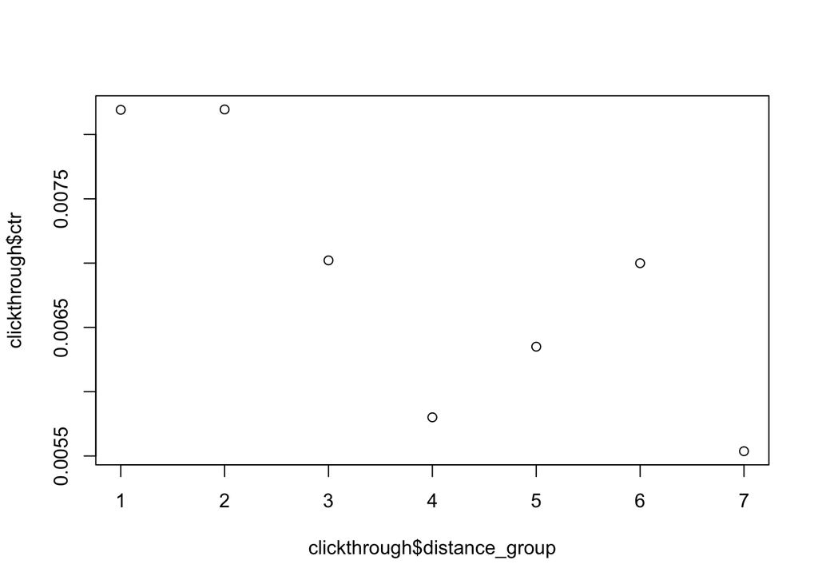

```r
plot(clickthrough$distance_group,clickthrough$ctr)
```

# Logistics Regression

- 1. Specify the following Logistic regression model: Dependent variable: didclick; Independent variables: distance, distance_squared, imp_large, cat_entertainment, cat_social, cat_tech, os_ios, ln_app_review_vol and app_review_val.

Create a new data frame including all predictors.

```r
mobile2 <- as.data.frame(mobile[,c("didclick", "distance", "distance_squared", "imp_large", "cat_entertainment",
                                   "cat_social", "cat_tech", "os_ios", "ln_app_review_vol", "app_review_val")])
```

Before fitting into the logistic regression model, let’s see the correlation between the predictors.

```r
res2 <- cor(mobile2)
res2
```

```
##                       didclick     distance distance_squared    imp_large
## didclick           1.000000000 -0.006628356     -0.004462031 -0.004786218
## distance          -0.006628356  1.000000000      0.955542600  0.020024918
## distance_squared  -0.004462031  0.955542600      1.000000000  0.029075052
## imp_large         -0.004786218  0.020024918      0.029075052  1.000000000
## cat_entertainment -0.007117972 -0.028992663     -0.038385249 -0.254731873
## cat_social        -0.005623417  0.060484490      0.055799705 -0.185311155
## cat_tech           0.012454366  0.023499545      0.034723464  0.414049273
## os_ios            -0.002147325 -0.060281389     -0.065060413 -0.190194050
## ln_app_review_vol  0.003982875 -0.157864184     -0.146892384  0.049929790
## app_review_val    -0.006523592  0.022481133      0.010750893 -0.321439020
##                   cat_entertainment   cat_social    cat_tech       os_ios
## didclick               -0.007117972 -0.005623417  0.01245437 -0.002147325
## distance               -0.028992663  0.060484490  0.02349954 -0.060281389
## distance_squared       -0.038385249  0.055799705  0.03472346 -0.065060413
## imp_large              -0.254731873 -0.185311155  0.41404927 -0.190194050
## cat_entertainment       1.000000000 -0.238133905 -0.65257568  0.312647684
## cat_social             -0.238133905  1.000000000 -0.39192721  0.513672844
## cat_tech               -0.652575678 -0.391927215  1.00000000 -0.598919227
## os_ios                  0.312647684  0.513672844 -0.59891923  1.000000000
## ln_app_review_vol      -0.105545185 -0.115376574  0.04950383 -0.013523794
## app_review_val          0.642212363  0.194394425 -0.73206714  0.366139311
##                   ln_app_review_vol app_review_val
## didclick                0.003982875   -0.006523592
## distance               -0.157864184    0.022481133
## distance_squared       -0.146892384    0.010750893
## imp_large               0.049929790   -0.321439020
## cat_entertainment      -0.105545185    0.642212363
## cat_social             -0.115376574    0.194394425
## cat_tech                0.049503835   -0.732067145
## os_ios                 -0.013523794    0.366139311
## ln_app_review_vol       1.000000000    0.014457854
## app_review_val          0.014457854    1.000000000
```

```r
round(res2, 4)
```

```
##                   didclick distance distance_squared imp_large
## didclick            1.0000  -0.0066          -0.0045   -0.0048
## distance           -0.0066   1.0000           0.9555    0.0200
## distance_squared   -0.0045   0.9555           1.0000    0.0291
## imp_large          -0.0048   0.0200           0.0291    1.0000
## cat_entertainment  -0.0071  -0.0290          -0.0384   -0.2547
## cat_social         -0.0056   0.0605           0.0558   -0.1853
## cat_tech            0.0125   0.0235           0.0347    0.4140
## os_ios             -0.0021  -0.0603          -0.0651   -0.1902
## ln_app_review_vol   0.0040  -0.1579          -0.1469    0.0499
## app_review_val     -0.0065   0.0225           0.0108   -0.3214
##                   cat_entertainment cat_social cat_tech  os_ios
## didclick                    -0.0071    -0.0056   0.0125 -0.0021
## distance                    -0.0290     0.0605   0.0235 -0.0603
## distance_squared            -0.0384     0.0558   0.0347 -0.0651
## imp_large                   -0.2547    -0.1853   0.4140 -0.1902
## cat_entertainment            1.0000    -0.2381  -0.6526  0.3126
## cat_social                  -0.2381     1.0000  -0.3919  0.5137
## cat_tech                    -0.6526    -0.3919   1.0000 -0.5989
## os_ios                       0.3126     0.5137  -0.5989  1.0000
## ln_app_review_vol           -0.1055    -0.1154   0.0495 -0.0135
## app_review_val               0.6422     0.1944  -0.7321  0.3661
##                   ln_app_review_vol app_review_val
## didclick                     0.0040        -0.0065
## distance                    -0.1579         0.0225
## distance_squared            -0.1469         0.0108
## imp_large                    0.0499        -0.3214
## cat_entertainment           -0.1055         0.6422
## cat_social                  -0.1154         0.1944
## cat_tech                     0.0495        -0.7321
## os_ios                      -0.0135         0.3661
## ln_app_review_vol            1.0000         0.0145
## app_review_val               0.0145         1.0000
```

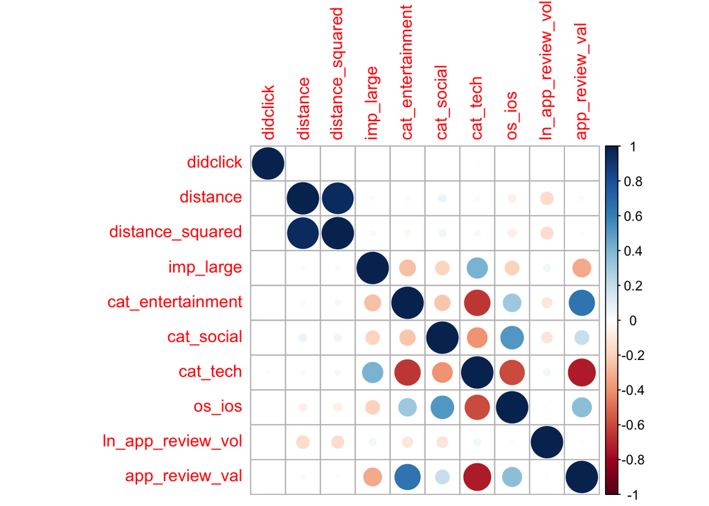

```r
corrplot(res2, method = "circle")
```

- 2. Estimate the model in R (using the glm function) and report coefficients and p-value of the estimates.

```r
reg1 <- glm(didclick ~ distance + distance_squared + imp_large + cat_entertainment
                   + cat_social + cat_tech + os_ios + ln_app_review_vol + app_review_val,
                   data = mobile2, family = binomial())

summary(reg1)
```

```
##
## Call:
## glm(formula = didclick ~ distance + distance_squared + imp_large +
##     cat_entertainment + cat_social + cat_tech + os_ios + ln_app_review_vol +
##     app_review_val, family = binomial(), data = mobile2)
##
## Deviance Residuals:
##     Min       1Q   Median       3Q      Max
## -0.1510  -0.1272  -0.1148  -0.1042   3.4025
##
## Coefficients:
##                    Estimate Std. Error z value Pr(>|z|)
## (Intercept)       -6.616818   0.896958  -7.377 1.62e-13 ***
## distance          -0.117927   0.045073  -2.616 0.008888 **
## distance_squared   0.009166   0.004362   2.102 0.035583 *
## imp_large         -0.352164   0.091782  -3.837 0.000125 ***
## cat_entertainment -0.096143   0.178941  -0.537 0.591069
## cat_social        -0.226695   0.211394  -1.072 0.283550
## cat_tech           0.687657   0.176312   3.900 9.61e-05 ***
## os_ios             0.385895   0.126361   3.054 0.002259 **
## ln_app_review_vol  0.030512   0.063037   0.484 0.628368
## app_review_val     0.323831   0.186656   1.735 0.082757 .
## ---
## Signif. codes:  0 '***' 0.001 '**' 0.01 '*' 0.05 '.' 0.1 ' ' 1
##
## (Dispersion parameter for binomial family taken to be 1)
##
##     Null deviance: 9912.5  on 121566  degrees of freedom
## Residual deviance: 9857.1  on 121557  degrees of freedom
## AIC: 9877.1
##
## Number of Fisher Scoring iterations: 8
```

Some of the variables are insignificant, let’s try adding some interaction terms.

```r
reg2 <- glm(didclick ~ log(distance) + distance_squared + imp_large + cat_entertainment + app_review_val*cat_entertainment
            + cat_social + cat_social*app_review_val +  cat_tech*imp_large + os_ios
            + app_review_val*os_ios + ln_app_review_vol  + app_review_val
            + distance*ln_app_review_vol + distance_squared*ln_app_review_vol,
            data = mobile2, family = binomial())
summary(reg2)
```

```
##
## Call:
## glm(formula = didclick ~ log(distance) + distance_squared + imp_large +
##     cat_entertainment + app_review_val * cat_entertainment +
##     cat_social + cat_social * app_review_val + cat_tech * imp_large +
##     os_ios + app_review_val * os_ios + ln_app_review_vol + app_review_val +
##     distance * ln_app_review_vol + distance_squared * ln_app_review_vol,
##     family = binomial(), data = mobile2)
##
## Deviance Residuals:
##     Min       1Q   Median       3Q      Max
## -0.3577  -0.1276  -0.1177  -0.1015   4.3105
##
## Coefficients:
##                                     Estimate Std. Error z value Pr(>|z|)
## (Intercept)                        -4.134473   1.682279  -2.458 0.013985
## log(distance)                       0.062151   0.128553   0.483 0.628764
## distance_squared                   -0.180217   0.092936  -1.939 0.052482
## imp_large                          -1.146428   0.392473  -2.921 0.003489
## cat_entertainment                  -5.047402   2.196867  -2.298 0.021588
## app_review_val                     -1.037735   0.314183  -3.303 0.000957
## cat_social                          4.686830   2.322538   2.018 0.043594
## cat_tech                            0.299243   0.170564   1.754 0.079357
## os_ios                             -6.922767   1.921620  -3.603 0.000315
## ln_app_review_vol                   0.283008   0.131999   2.144 0.032032
## distance                            2.249675   0.877819   2.563 0.010383
## cat_entertainment:app_review_val    1.289929   0.552798   2.333 0.019624
## app_review_val:cat_social          -1.272401   0.619175  -2.055 0.039880
## imp_large:cat_tech                  0.867968   0.404154   2.148 0.031744
## app_review_val:os_ios               1.925950   0.477233   4.036 5.44e-05
## ln_app_review_vol:distance         -0.237950   0.088351  -2.693 0.007076
## distance_squared:ln_app_review_vol  0.018894   0.009358   2.019 0.043481
##
## (Intercept)                        *
## log(distance)
## distance_squared                   .
## imp_large                          **
## cat_entertainment                  *
## app_review_val                     ***
## cat_social                         *
## cat_tech                           .
## os_ios                             ***
## ln_app_review_vol                  *
## distance                           *
## cat_entertainment:app_review_val   *
## app_review_val:cat_social          *
## imp_large:cat_tech                 *
## app_review_val:os_ios              ***
## ln_app_review_vol:distance         **
## distance_squared:ln_app_review_vol *
## ---
## Signif. codes:  0 '***' 0.001 '**' 0.01 '*' 0.05 '.' 0.1 ' ' 1
##
## (Dispersion parameter for binomial family taken to be 1)
##
##     Null deviance: 9912.5  on 121566  degrees of freedom
## Residual deviance: 9779.1  on 121550  degrees of freedom
## AIC: 9813.1
##
## Number of Fisher Scoring iterations: 8
```

We can see model 2 has a lower AIC score, which means it’s an imoroved model. We can also calculate the McFadden’s Pseudo R-squared for the two models.

```r
nullmod1 <- glm(didclick~1, data  = mobile2, family="binomial")
1-logLik(reg1)/logLik(nullmod1)
```

```
## 'log Lik.' 0.005590261 (df=10)
```

```r
nullmod2 <- glm(didclick~1, data  = mobile2, family="binomial")
1-logLik(reg2)/logLik(nullmod2)
```

```
## 'log Lik.' 0.01345077 (df=17)
```

- Diagnostic test for logistic regression

step 1: residual plot

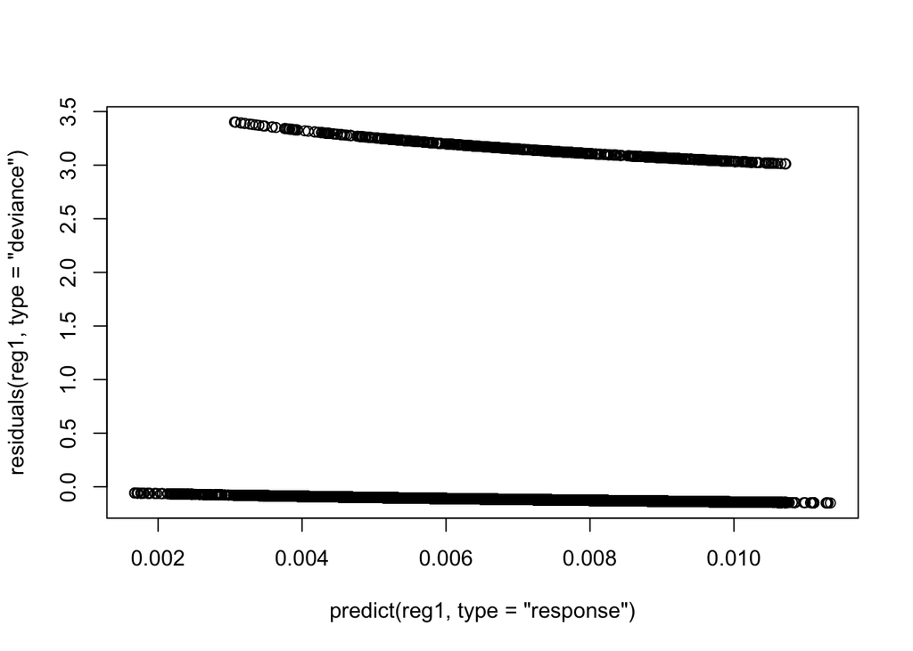

```r
plot(predict(reg1, type="response"),
             residuals(reg1, type= "deviance"))
```

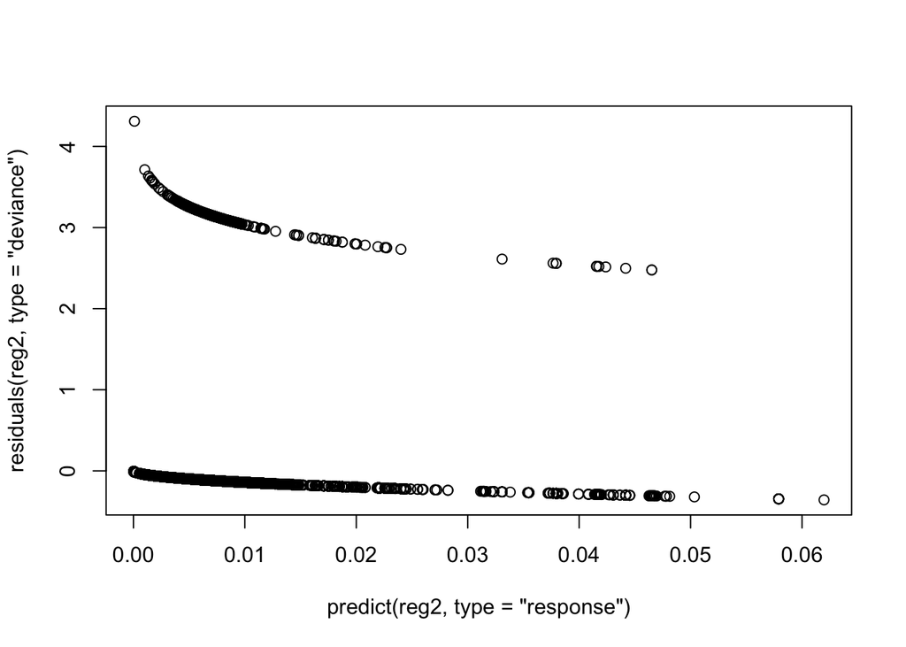

```r
plot(predict(reg2, type="response"),
             residuals(reg2, type= "deviance"))
```

step 2: influential plots

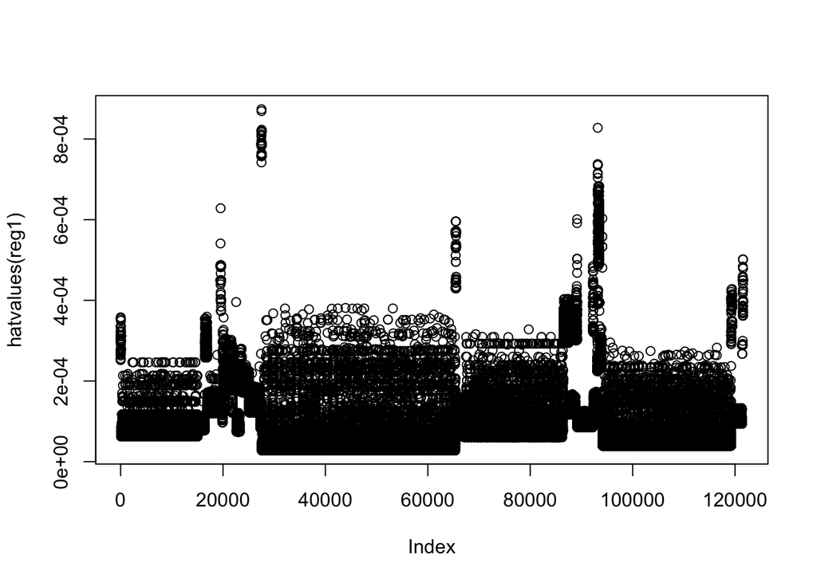

```r
plot(hatvalues(reg1))
```

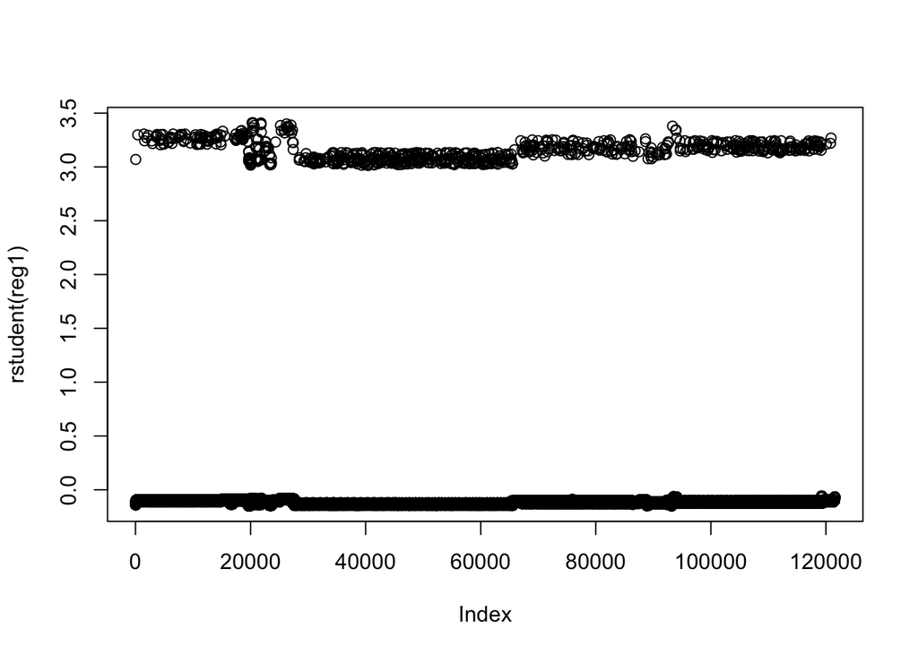

```r
plot(rstudent(reg1))
```

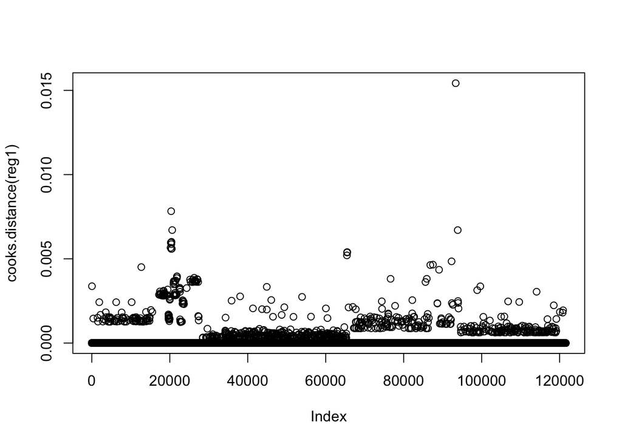

```r
plot(cooks.distance(reg1))
```

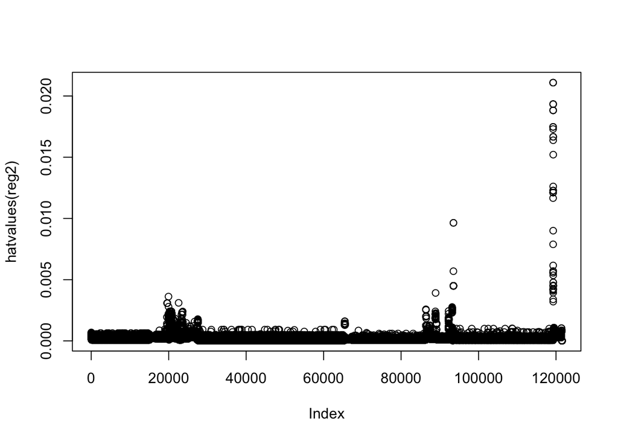

```r
plot(hatvalues(reg2))
```

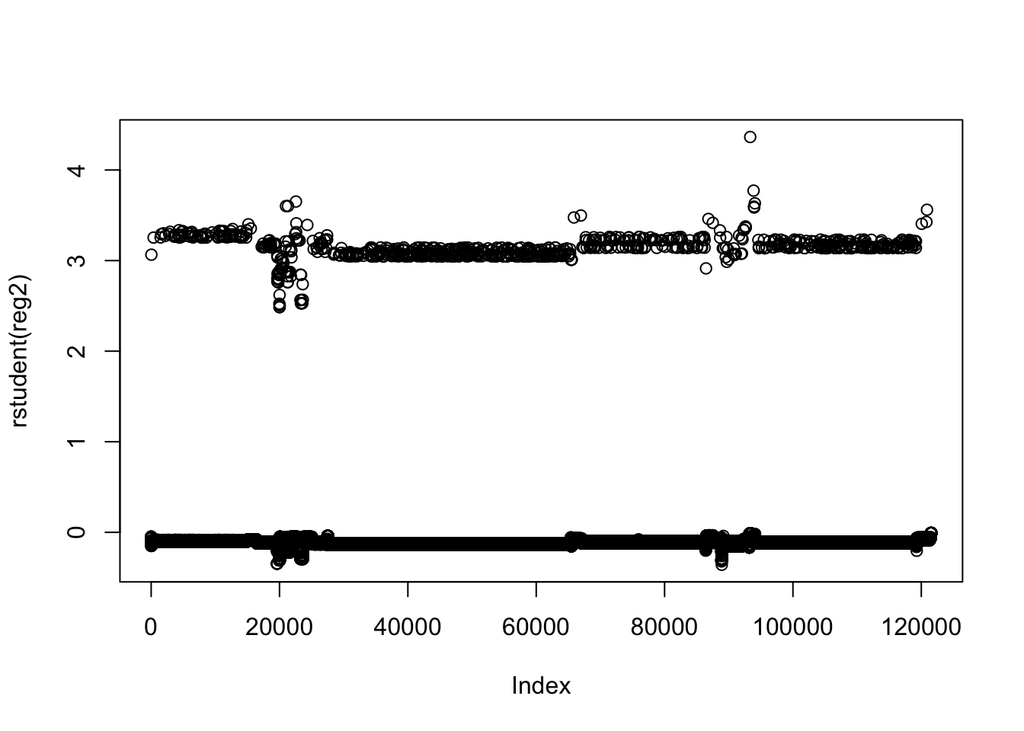

```r
plot(rstudent(reg2))
```

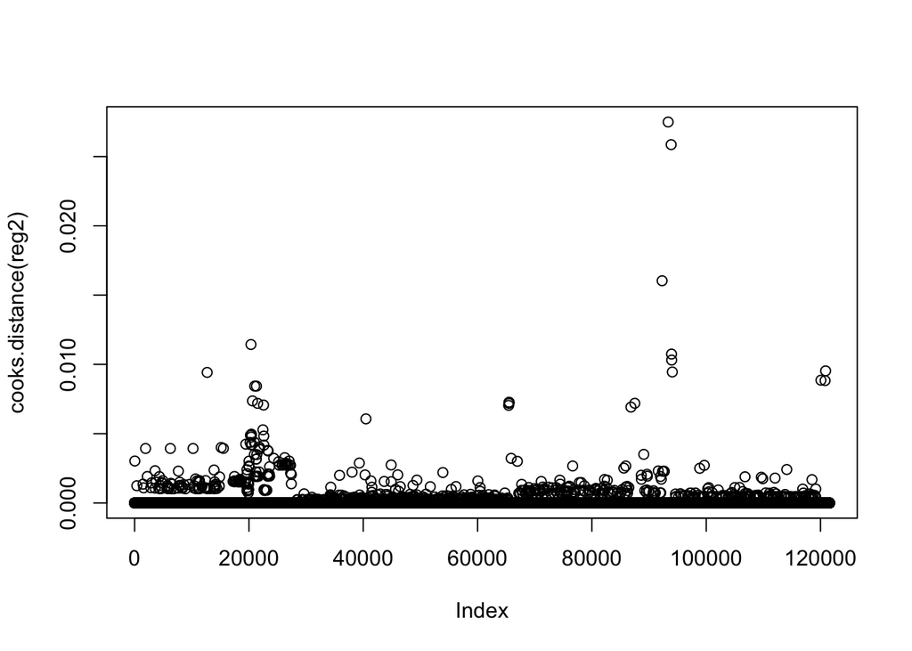

```r
plot(cooks.distance(reg2))
```

step 3: overdispersion

The expected variance for data drawn from a binomial distribution is σ2 = nπ(1 − π), where n is the number of observations and π is the probability of belonging to the Y = 1 group. Overdispersion occurs when the observed variance of the response variable is larger than what would be expected from a binomial distribution. Overdispersion can lead to distorted test standard errors and inaccurate tests of significance.

One way to detect overdispersion is to compare the residual deviance with the residual degrees of freedom in your binomial model. If the ratio is considerably larger than 1, you have evidence of overdispersion. Applying this to the mobile example, I have

```r
deviance(reg2)/df.residual(reg2)
```

```
## [1] 0.08045368
```

With logistic regression, overdispersion is suggested if the ratio of the residual deviance to the residual degrees of freedom is much larger than 1, which is not our case here.

We will choose the second model as the final model.

Recall:

```
##
## Call:
## glm(formula = didclick ~ log(distance) + distance_squared + imp_large +
##     cat_entertainment + app_review_val * cat_entertainment +
##     cat_social + cat_social * app_review_val + cat_tech * imp_large +
##     os_ios + app_review_val * os_ios + ln_app_review_vol + app_review_val +
##     distance * ln_app_review_vol + distance_squared * ln_app_review_vol,
##     family = binomial(), data = mobile2)
##
## Deviance Residuals:
##     Min       1Q   Median       3Q      Max
## -0.3577  -0.1276  -0.1177  -0.1015   4.3105
##
## Coefficients:
##                                     Estimate Std. Error z value Pr(>|z|)
## (Intercept)                        -4.134473   1.682279  -2.458 0.013985
## log(distance)                       0.062151   0.128553   0.483 0.628764
## distance_squared                   -0.180217   0.092936  -1.939 0.052482
## imp_large                          -1.146428   0.392473  -2.921 0.003489
## cat_entertainment                  -5.047402   2.196867  -2.298 0.021588
## app_review_val                     -1.037735   0.314183  -3.303 0.000957
## cat_social                          4.686830   2.322538   2.018 0.043594
## cat_tech                            0.299243   0.170564   1.754 0.079357
## os_ios                             -6.922767   1.921620  -3.603 0.000315
## ln_app_review_vol                   0.283008   0.131999   2.144 0.032032
## distance                            2.249675   0.877819   2.563 0.010383
## cat_entertainment:app_review_val    1.289929   0.552798   2.333 0.019624
## app_review_val:cat_social          -1.272401   0.619175  -2.055 0.039880
## imp_large:cat_tech                  0.867968   0.404154   2.148 0.031744
## app_review_val:os_ios               1.925950   0.477233   4.036 5.44e-05
## ln_app_review_vol:distance         -0.237950   0.088351  -2.693 0.007076
## distance_squared:ln_app_review_vol  0.018894   0.009358   2.019 0.043481
##
## (Intercept)                        *
## log(distance)
## distance_squared                   .
## imp_large                          **
## cat_entertainment                  *
## app_review_val                     ***
## cat_social                         *
## cat_tech                           .
## os_ios                             ***
## ln_app_review_vol                  *
## distance                           *
## cat_entertainment:app_review_val   *
## app_review_val:cat_social          *
## imp_large:cat_tech                 *
## app_review_val:os_ios              ***
## ln_app_review_vol:distance         **
## distance_squared:ln_app_review_vol *
## ---
## Signif. codes:  0 '***' 0.001 '**' 0.01 '*' 0.05 '.' 0.1 ' ' 1
##
## (Dispersion parameter for binomial family taken to be 1)
##
##     Null deviance: 9912.5  on 121566  degrees of freedom
## Residual deviance: 9779.1  on 121550  degrees of freedom
## AIC: 9813.1
##
## Number of Fisher Scoring iterations: 8
```

```r
coef(reg2)
```

```
##                        (Intercept)                      log(distance)
##                        -4.13447269                         0.06215146
##                   distance_squared                          imp_large
##                        -0.18021662                        -1.14642790
##                  cat_entertainment                     app_review_val
##                        -5.04740172                        -1.03773495
##                         cat_social                           cat_tech
##                         4.68683009                         0.29924264
##                             os_ios                  ln_app_review_vol
##                        -6.92276709                         0.28300834
##                           distance   cat_entertainment:app_review_val
##                         2.24967541                         1.28992918
##          app_review_val:cat_social                 imp_large:cat_tech
##                        -1.27240063                         0.86796831
##              app_review_val:os_ios         ln_app_review_vol:distance
##                         1.92595029                        -0.23794965
## distance_squared:ln_app_review_vol
##                         0.01889372
```

In a logistic regression, the response being modeled is the log(odds) that Y = 1. The regression coefficients give the change in log(odds) in the response for a unit change in the predictor variable, holding all other predictor variables constant. Because log(odds) are difficult to interpret, we can exponentiate them to put the results on an odds scale:

```r
exp(coef(reg2))
```

```
##                        (Intercept)                      log(distance)
##                       1.601111e-02                       1.064124e+00
##                   distance_squared                          imp_large
##                       8.350893e-01                       3.177699e-01
##                  cat_entertainment                     app_review_val
##                       6.426008e-03                       3.542562e-01
##                         cat_social                           cat_tech
##                       1.085087e+02                       1.348837e+00
##                             os_ios                  ln_app_review_vol
##                       9.851003e-04                       1.327116e+00
##                           distance   cat_entertainment:app_review_val
##                       9.484657e+00                       3.632529e+00
##          app_review_val:cat_social                 imp_large:cat_tech
##                       2.801583e-01                       2.382066e+00
##              app_review_val:os_ios         ln_app_review_vol:distance
##                       6.861666e+00                       7.882424e-01
## distance_squared:ln_app_review_vol
##                       1.019073e+00
```

The odds of an impression click increase with log(distance), cat_social, cat_tech, ln_app_review_vol, imp_large:cat_tech, app_review_val:os_ios, distance_squared:ln_app_review_vol, and decrease with distance_squared, imp_large, cat_entertainment, app_review_val, os_ios, app_review_val:cat_social and distance:ln_app_review_vol.

The interaction terms such as app_review_val:os_ios, means the relationship bewteen app_review_val and whether a user clicked the impression, depending on whether the user is using an ios device or not.

- 3. Findings and their implications